# Importing and installing libraries

```python
from importlib.metadata import version
```

```python
pip install mediacloud
```

```python
pip install python-dotenv
```

```python
pip install pandas
```

```python
pip install seaborn
```

```python
pip install wordcloud
```

```python
pip install spacy
```

```python
import pandas as pd   #data cleaning and wrangling
import mediacloud.api #data collection
import inspect        #understanding poorly documented APIs/libraries

from datetime import datetime        #managing publication dates
from calendar import monthrange      #working with time loops and monthly queries (data collection)
import time                          #handling with APIs rate time limits
from datetime import date, timedelta #temporal operations
import os                            #operating with the operating system
import pprint                        #print data structure in a readable way (e.g., API responses)
from pathlib import Path             #more sofisticated path/file management
import glob                          #look for file matching on the basis of a pattern

import seaborn as sns              #visualizing coverage trends
import matplotlib.pyplot as plt    #base library to plot
import matplotlib.dates as mdates  #specialized module for time series
import re                          #regex
```

# Personal API key

```python
API_key = "8e6e80ca06afa15cd5f58fab33f6dc5d457fe2da"
```

```python
#Creating the client

mc = mediacloud.api.SearchApi(API_key)

print(inspect.signature(mc.story_list))
```

```
(query: str, start_date: datetime.date, end_date: datetime.date, collection_ids: Optional[List[int]] = [], source_ids: Optional[List[int]] = [], platform: Optional[str] = None, expanded: Optional[bool] = None, pagination_token: Optional[str] = None, sort_order: Optional[str] = None, page_size: Optio…
```

```python
#Creating a Client for API directory

directory_api = mediacloud.api.DirectoryApi(API_key)
f'Using Media Cloud python client v{version("mediacloud")}'
```

```python
# search for a collection by name

italian_collections = directory_api.collection_list(name='italy')
[c['name'] for c in italian_collections['results']]
```

```python
# page through a list of all the sources in the "Italy - National" collection
ITALY_NATIONAL = 34412372
sources_collection = []
limit = 100
offset = 0
while True:
    response = directory_api.source_list(collection_id=ITALY_NATIONAL, limit=limit, offset=offset)
    sources_collection += response['results']
    if response['next'] is None:
        break
    offset += limit
f"Found {len(sources_collection)} media sources in Italy National collection geographic collections"
```

```python
print(type(sources_collection))
for key in sources_collection[0].keys():
    print(key)
```

```python
pprint.pprint(sources_collection[0])
```

```python
df_sources = pd.json_normalize(sources_collection)
print(df_sources.columns)
df_sources[["id","name","label","media_type","platform"]]
```

## Data collection

News data were collected through the SearchAPI service for three Italian newspaper outlets selected according to ADS readership data for 2017. The sample was constructed to capture variation in both journalistic style and political orientation.

Selected outlets:

- La Repubblica (ID: 41552) — quality/progressive newspaper
- Corriere della Sera (ID: 39529) — quality/conservative newspaper
- Libero (ID: 308994) — right-wing populist tabloid

Reference year: 2016

## Metadata

```python
START = date(2016, 1, 1)
END = date(2016, 12, 31)

sources = {
    41552: "La Repubblica",
    39529: "Il Corriere della Sera",
    308994: "Libero"
}

rows = []

for source_id, source_name in sources.items():
    results = mc.story_count_over_time(
        "*",
        START,
        END,
        source_ids=[source_id]
    )

    for r in results:
        rows.append({
            "source_id": source_id,
            "media_name": source_name,
            "date": r["date"],
            "total_stories": r["count"],
        })

denominator1 = pd.DataFrame(rows)
denominator1 = denominator1.rename(columns={"date": "publish_date"})
```

```python
START = date(2017, 6, 11)
END = date(2018, 2, 19)

sources = {
    41552: "La Repubblica",
    39529: "Il Corriere della Sera",
    308994: "Libero"
}

rows = []

for source_id, source_name in sources.items():
    results = mc.story_count_over_time(
        "*",
        START,
        END,
        source_ids=[source_id]
    )

    for r in results:
        rows.append({
            "source_id": source_id,
            "media_name": source_name,
            "date": r["date"],
            "total_stories": r["count"],
        })

denominator2 = pd.DataFrame(rows)
denominator2 = denominator2.rename(columns={"date": "publish_date"})
```

```python
# Merging datasets

denominator = pd.concat(
    [denominator1, denominator2],
    axis=0,
    ignore_index=True
)
denominator.head()
```

|  | source_id | media_name | publish_date | total_stories |
| --- | --- | --- | --- | --- |
| 0 | 41552 | La Repubblica | 2016-01-01 | 120 |
| 1 | 41552 | La Repubblica | 2016-01-02 | 167 |
| 2 | 41552 | La Repubblica | 2016-01-03 | 139 |
| 3 | 41552 | La Repubblica | 2016-01-04 | 207 |
| 4 | 41552 | La Repubblica | 2016-01-05 | 236 |

```python
denominator["publish_date"] = pd.to_datetime(denominator["publish_date"])

denominator["full_2016"] = (
    (denominator["publish_date"] >= "2016-01-01") &
    (denominator["publish_date"] <= "2016-12-31")
).astype(int)

denominator["pre_interview"] = (
    (denominator["publish_date"] >= "2017-06-11") &
    (denominator["publish_date"] <= "2017-11-19")
).astype(int)

denominator["post_interview"] = (
    (denominator["publish_date"] >= "2017-09-11") &
    (denominator["publish_date"] <= "2018-02-19")
).astype(int)

denominator.head()
```

|  | source_id | media_name | publish_date | total_stories | full_2016 | pre_interview | post_interview |
| --- | --- | --- | --- | --- | --- | --- | --- |
| 0 | 41552 | La Repubblica | 2016-01-01 | 120 | 1 | 0 | 0 |
| 1 | 41552 | La Repubblica | 2016-01-02 | 167 | 1 | 0 | 0 |
| 2 | 41552 | La Repubblica | 2016-01-03 | 139 | 1 | 0 | 0 |
| 3 | 41552 | La Repubblica | 2016-01-04 | 207 | 1 | 0 | 0 |
| 4 | 41552 | La Repubblica | 2016-01-05 | 236 | 1 | 0 | 0 |

```python
denominator_2016 = denominator[denominator["full_2016"] == 1].copy()
denominator_2016["year"] = denominator_2016["publish_date"].dt.year

country_yearly_total = (
    denominator_2016
    .groupby("year", as_index=False)["total_stories"]
    .sum()
    .rename(columns={"total_stories": "country_total_stories_2016"})
)

media_yearly_total = (
    denominator_2016
    .groupby(["source_id", "media_name", "year"], as_index=False)["total_stories"]
    .sum()
    .rename(columns={"total_stories": "media_total_stories_2016"})
)
```

```python
#Saving the dataset
country_yearly_total.to_csv("ITA_country_total.csv", index=False, encoding="utf-8")
media_yearly_total.to_csv("ITA_media_total.csv", index=False, encoding="utf-8")
```

```python
#Grouping news per month

denominator_int = denominator[(denominator["pre_interview"] == 1) | (denominator["post_interview"] == 1)].copy()
denominator_int["month"] = denominator_int["publish_date"].dt.to_period("M").astype(str)
denominator_int.head()
```

|  | source_id | media_name | publish_date | total_stories | full_2016 | pre_interview | post_interview | month |
| --- | --- | --- | --- | --- | --- | --- | --- | --- |
| 1059 | 41552 | La Repubblica | 2017-06-11 | 164 | 0 | 1 | 0 | 2017-06 |
| 1060 | 41552 | La Repubblica | 2017-06-12 | 242 | 0 | 1 | 0 | 2017-06 |
| 1061 | 41552 | La Repubblica | 2017-06-13 | 290 | 0 | 1 | 0 | 2017-06 |
| 1062 | 41552 | La Repubblica | 2017-06-14 | 276 | 0 | 1 | 0 | 2017-06 |
| 1063 | 41552 | La Repubblica | 2017-06-15 | 271 | 0 | 1 | 0 | 2017-06 |

```python
country_monthly_total = (
    denominator_int
    .groupby("month", as_index=False)["total_stories"]
    .sum()
    .rename(columns={"total_stories": "country_total_stories_month"})
)

media_monthly_total = (
    denominator_int
    .groupby(["source_id", "media_name", "month"], as_index=False)["total_stories"]
    .sum()
    .rename(columns={"total_stories": "media_total_stories_month"})
)
```

```python
#Saving the dataset
country_monthly_total.to_csv("ITA_country_month.csv", index=False, encoding="utf-8")
media_monthly_total.to_csv("ITA_media_month.csv", index=False, encoding="utf-8")
```

# Data wrangling

The data cleaning procedure involved the following steps:

- Removal of non-informative variables: indexed_date, media_url, url
- Cleaning up of cases that may be source of noise: language [=it], only title including words related to migration, removal of duplicates
- Reconding of variables in a more readable way: media_name

```python
#Opening the file

df_imm_2016 = pd.read_csv("IT_2016_stories.csv")
df_imm_2016.head()

df_imm_pre = pd.read_csv("IT_pre_stories.csv")
df_imm_pre.head()

df_imm_post = pd.read_csv("IT_post_stories.csv")
df_imm_post.head()

df_imm_int = pd.read_csv("IT_int_stories.csv")
df_imm_int.head()
```

|  | id | indexed_date | language | media_name | media_url | publish_date | title | url |
| --- | --- | --- | --- | --- | --- | --- | --- | --- |
| 0 | aec4a6fce56a4eed16c0363a99d144b191c672626a1808... | 2025-08-15 17:41:48.421311+00:00 | it | repubblica.it | repubblica.it | 2017-09-22 | Firenze, premio cittadino europeo: tra i vinci... | http://firenze.repubblica.it/cronaca/2017/09/2... |
| 1 | aa659665ae184fd5af359f927c059410baa31b2c2ad516... | 2025-08-15 17:40:40.800956+00:00 | it | repubblica.it | repubblica.it | 2017-09-22 | Milano pronta per la Settimana della Musica: i... | http://milano.repubblica.it/cronaca/2017/09/22... |
| 2 | 7b69a08dadc15bda9bcacbda6d81b2b60f154633ed2dd5... | 2025-08-15 17:40:30.589836+00:00 | it | liberoquotidiano.it | liberoquotidiano.it | 2017-09-22 | Il 27 ottobre la maratona per città green, già... | http://www.liberoquotidiano.it/news/sostenibil... |
| 3 | 8a733945e2e35391946bb51e8a8bbc4decf8f41ff34342... | 2025-08-15 17:40:28.276452+00:00 | it | repubblica.it | repubblica.it | 2017-09-21 | Google compra gli smartphone di Htc per 1,1 mi... | http://www.repubblica.it/tecnologia/2017/09/21... |
| 4 | 5ca997506b9eb9be31ac1d62c36fb458d00964f2c8bb08... | 2025-08-15 17:38:40.468560+00:00 | it | repubblica.it | repubblica.it | 2017-09-22 | "Non si affitta casa agli stranieri". Bologna,... | http://bologna.repubblica.it/cronaca/2017/09/2... |

```python
# Merging datasets

df_imm = pd.concat(
    [df_imm_2016, df_imm_pre, df_imm_post, df_imm_int],
    axis=0,
    ignore_index=True
)
df_imm.head()
```

|  | id | indexed_date | language | media_name | media_url | publish_date | title | url |
| --- | --- | --- | --- | --- | --- | --- | --- | --- |
| 0 | f02fca7636c09f9b899f7bd1a1d407741ca8c7fb97a90f... | 2025-08-25 04:26:23.923404+00:00 | it | repubblica.it | repubblica.it | 2016-01-01 | Merkel ai tedeschi: "Migranti sono un'opportun... | http://www.repubblica.it/esteri/2016/01/01/new... |
| 1 | 9c03dcc9bc63acdb0e50d64ebff02edfcd6dfb77f4ffa4... | 2025-08-25 03:33:02.974579+00:00 | it | corriere.it | corriere.it | 2016-10-10 | Immobili, il settore retail supera la crisi, m... | http://passaparola.corriere.it/community/perma... |
| 2 | 29699f91661884f5dada0ab65acc314dd07e02e1ec4aac... | 2025-08-25 03:32:35.296147+00:00 | it | repubblica.it | repubblica.it | 2016-10-10 | Bologna, gli agenti della polizia ferroviaria ... | http://bologna.repubblica.it/cronaca/2016/10/1... |
| 3 | 70d6f12d71da9caeeb2b25af3b9bb32a5807f337e65759... | 2025-08-25 03:32:35.196191+00:00 | it | repubblica.it | repubblica.it | 2016-10-10 | Bologna e Impact, nasce la Coppa Saputo per le... | http://bologna.repubblica.it/sport/2016/10/10/... |
| 4 | b55b0033f4364c99702333a08c27ca1cf30955b9663241... | 2025-08-25 03:31:52.575760+00:00 | it | repubblica.it | repubblica.it | 2016-10-10 | Roma, in piazza il posto auto riservato del pr... | http://roma.repubblica.it/cronaca/2016/10/10/f... |

```python
df_imm["publish_date"].agg(["min", "max"])
```

```
min    2016-01-01
max    2018-02-19
Name: publish_date, dtype: str
```

```python
#Sample categories
df_imm["publish_date"] = pd.to_datetime(df_imm["publish_date"])

df_imm["full_2016"] = (
    (df_imm["publish_date"] >= "2016-01-01") &
    (df_imm["publish_date"] <= "2016-12-31")
).astype(int)

df_imm["pre_interview"] = (
    (df_imm["publish_date"] >= "2017-06-11") &
    (df_imm["publish_date"] <= "2017-11-19")
).astype(int)

df_imm["post_interview"] = (
    (df_imm["publish_date"] >= "2017-09-11") &
    (df_imm["publish_date"] <= "2018-02-19")
).astype(int)

df_imm.head()
```

|  | id | indexed_date | language | media_name | media_url | publish_date | title | url | full_2016 | pre_interview | post_interview |
| --- | --- | --- | --- | --- | --- | --- | --- | --- | --- | --- | --- |
| 0 | f02fca7636c09f9b899f7bd1a1d407741ca8c7fb97a90f... | 2025-08-25 04:26:23.923404+00:00 | it | repubblica.it | repubblica.it | 2016-01-01 | Merkel ai tedeschi: "Migranti sono un'opportun... | http://www.repubblica.it/esteri/2016/01/01/new... | 1 | 0 | 0 |
| 1 | 9c03dcc9bc63acdb0e50d64ebff02edfcd6dfb77f4ffa4... | 2025-08-25 03:33:02.974579+00:00 | it | corriere.it | corriere.it | 2016-10-10 | Immobili, il settore retail supera la crisi, m... | http://passaparola.corriere.it/community/perma... | 1 | 0 | 0 |
| 2 | 29699f91661884f5dada0ab65acc314dd07e02e1ec4aac... | 2025-08-25 03:32:35.296147+00:00 | it | repubblica.it | repubblica.it | 2016-10-10 | Bologna, gli agenti della polizia ferroviaria ... | http://bologna.repubblica.it/cronaca/2016/10/1... | 1 | 0 | 0 |
| 3 | 70d6f12d71da9caeeb2b25af3b9bb32a5807f337e65759... | 2025-08-25 03:32:35.196191+00:00 | it | repubblica.it | repubblica.it | 2016-10-10 | Bologna e Impact, nasce la Coppa Saputo per le... | http://bologna.repubblica.it/sport/2016/10/10/... | 1 | 0 | 0 |
| 4 | b55b0033f4364c99702333a08c27ca1cf30955b9663241... | 2025-08-25 03:31:52.575760+00:00 | it | repubblica.it | repubblica.it | 2016-10-10 | Roma, in piazza il posto auto riservato del pr... | http://roma.repubblica.it/cronaca/2016/10/10/f... | 1 | 0 | 0 |

```python
df_imm.drop(columns=["indexed_date", "media_url", "url"], inplace=True)
df_imm.head()
```

|  | id | language | media_name | publish_date | title | full_2016 | pre_interview | post_interview |
| --- | --- | --- | --- | --- | --- | --- | --- | --- |
| 0 | f02fca7636c09f9b899f7bd1a1d407741ca8c7fb97a90f... | it | repubblica.it | 2016-01-01 | Merkel ai tedeschi: "Migranti sono un'opportun... | 1 | 0 | 0 |
| 1 | 9c03dcc9bc63acdb0e50d64ebff02edfcd6dfb77f4ffa4... | it | corriere.it | 2016-10-10 | Immobili, il settore retail supera la crisi, m... | 1 | 0 | 0 |
| 2 | 29699f91661884f5dada0ab65acc314dd07e02e1ec4aac... | it | repubblica.it | 2016-10-10 | Bologna, gli agenti della polizia ferroviaria ... | 1 | 0 | 0 |
| 3 | 70d6f12d71da9caeeb2b25af3b9bb32a5807f337e65759... | it | repubblica.it | 2016-10-10 | Bologna e Impact, nasce la Coppa Saputo per le... | 1 | 0 | 0 |
| 4 | b55b0033f4364c99702333a08c27ca1cf30955b9663241... | it | repubblica.it | 2016-10-10 | Roma, in piazza il posto auto riservato del pr... | 1 | 0 | 0 |

```python
print("\n", df_imm["language"].value_counts())
```

```
 language
it    84582
Name: count, dtype: int64
```

```python
print("\n", df_imm["media_name"].value_counts())
```

```
 media_name
repubblica.it          36023
corriere.it            35436
liberoquotidiano.it    13123
Name: count, dtype: int64
```

```python
#Recoding media_name

media_out_ita = {
    "repubblica.it": "La Repubblica",
    "liberoquotidiano.it": "Libero",
    "corriere.it": "Il Corriere della Sera"
}

df_imm["media_name"] = df_imm["media_name"].replace(media_out_ita)

df_imm.head()#check
```

|  | id | language | media_name | publish_date | title | full_2016 | pre_interview | post_interview |
| --- | --- | --- | --- | --- | --- | --- | --- | --- |
| 0 | f02fca7636c09f9b899f7bd1a1d407741ca8c7fb97a90f... | it | La Repubblica | 2016-01-01 | Merkel ai tedeschi: "Migranti sono un'opportun... | 1 | 0 | 0 |
| 1 | 9c03dcc9bc63acdb0e50d64ebff02edfcd6dfb77f4ffa4... | it | Il Corriere della Sera | 2016-10-10 | Immobili, il settore retail supera la crisi, m... | 1 | 0 | 0 |
| 2 | 29699f91661884f5dada0ab65acc314dd07e02e1ec4aac... | it | La Repubblica | 2016-10-10 | Bologna, gli agenti della polizia ferroviaria ... | 1 | 0 | 0 |
| 3 | 70d6f12d71da9caeeb2b25af3b9bb32a5807f337e65759... | it | La Repubblica | 2016-10-10 | Bologna e Impact, nasce la Coppa Saputo per le... | 1 | 0 | 0 |
| 4 | b55b0033f4364c99702333a08c27ca1cf30955b9663241... | it | La Repubblica | 2016-10-10 | Roma, in piazza il posto auto riservato del pr... | 1 | 0 | 0 |

```python
descriptives_date = (
    df_imm
    .groupby("media_name")
    .agg(
        min_date=("publish_date", "min"),
        max_date=("publish_date", "max"),
        n_stories=("publish_date", "count")
    )
    .reset_index()
)

descriptives_date
```

|  | media_name | min_date | max_date | n_stories |
| --- | --- | --- | --- | --- |
| 0 | Il Corriere della Sera | 2016-01-01 | 2018-02-19 | 35436 |
| 1 | La Repubblica | 2016-01-01 | 2018-02-19 | 36023 |
| 2 | Libero | 2016-01-02 | 2018-02-19 | 13123 |

NOTE: No news for *Libero* before 02 January 2016

```python
#News outlet categories
outlet_categories = {
    "La Repubblica": "Quality Progressive",
    "Il Corriere della Sera": "Quality Conservative",
    "Libero": "Popular"
}

df_imm["media_categories"] = (
    df_imm["media_name"].map(outlet_categories)
)
```

```python
#Overview of the results
for i in range(10):
    print(f"\nARTICLE {i+1}")
    print("TITLE:", df_imm.loc[i, "title"])
```

```
ARTICLE 1
TITLE: Merkel ai tedeschi: "Migranti sono un'opportunità". Hollande: "Non abbiamo finito con il terrorismo"

ARTICLE 2
TITLE: Immobili, il settore retail supera la crisi, ma non in tutta Italia

ARTICLE 3
TITLE: Bologna, gli agenti della polizia ferroviaria sotto sfratto

ARTICLE 4
TITLE: Bologna e Impact, nasce la Coppa Saputo per le scuole di città e provincia

ARTICLE 5
TITLE: Roma, in piazza il posto auto riservato del presidente M5s del municipio III

ARTICLE 6
TITLE: Moscovici all'Eurogruppo: "Disponibili con l'Italia, ma sia seria sul deficit"

ARTICLE 7
TITLE: Selvaggia lite tra due amici ubriachi a Ivrea: uno finisce in ospedale, l'altro in prigione

ARTICLE 8
TITLE: Anti-Trump e pro-Palestina Roger Waters chiude il Desert Trip

ARTICLE 9
TITLE: Impiegati da tutto il mondo «Babele? In Posta funziona»

ARTICLE 10
TITLE: I carabinieri arrestano due rom accusati di sequestro di persona
```

### Cleaning up for title

Dictionary-based filtering of migration-related news articles using a rule-based textual classification approach.

The regex pattern is constructed as:

- a raw string (r"...")
- bounded by word boundaries (\b) to avoid partial-word matches
- a non-capturing group (?:...) containing alternative migration-related keywords

```python
#Filtering the news (=rows) whose "title" use of the "migration_ita_regex" words

migration_ita_regex = (
    r"\b(?:"
    #core migration terms
    r"immigrat\w*|emigrat\w*|migrant\w*|migratoria|immigrazione|emigrazione|migrazione|"
    r"nato all['’]estero|nata all['’]estero|nati all['’]estero|nate all['’]estero|stranier\w*|"
    #legal status and protection
    r"rifugiat\w*|asilo politico|richiedente asilo|richiedenti asilo|protezione internazionale|"
    r"profug\w*|apolid\w*|senza patria|"
    #irregular migration
    r"trafficanti di esseri umani|trafficante di esseri umani|rimpatr\w*|espuls\w*|espellere|frontex|"
    #reception and asylum systems
    r"sistema d['’]asilo|sistema di asilo|procedura di asilo|procedura per l['’]asilo|"
    r"centri di permanenza per il rimpatrio|cpr|sistema di accoglienza e integrazione|sai|"
    r"centri di accoglienza straordinaria|cas|convenzione di dublino|accordi di dublino|regolamento di dublino|"
    #legal migration and permits
    r"permesso di soggiorno|permessi di soggiorno|visto da residente|visti da residente|"
    r"ricongiungimento familiare|ricongiungimenti familiari|residente permanente|residenti permanenti|"
    #citizenship debate
    r"cittadinanza|naturalizzazione|cittadin\w*|naturalizzat\w*|ius soli|ius sanguinis|"
    r"ius scholae|ius culturae|nazionalità|"
    #biggest migrants group
    r"rumeno|rumena|rumeni|rumene|"
    r"albanese|albanesi|"
    r"marocchino|marocchina|marocchini|marocchine|"
    r"cinese|cinesi|"
    r"ucraino|ucraina|ucraini|ucraine"
    r")\b"
)

# Filter the dataset by selecting articles whose title contains at least one migration-related keyword included in the dictionary.
# The search is: case-insensitive, regex-based, robust to missing values

df_imm = df_imm[
    df_imm["title"].str.contains(migration_ita_regex, case=False, na=False, regex=True)
]
```

```python
print("Number of remaining articles:", len(df_imm_2016))
df_imm["title"].head(20)
```

```
Number of remaining articles: 45904
```

```
0      Merkel ai tedeschi: "Migranti sono un'opportun...
16                        La cinese Wanda e il no di Ubs
62     Terrorismo, il ministro Alfano: «Espulso alger...
73     Apple, iPhone con doppia sim per il mercato ci...
74     Manomorta in metrò: la ragazza cinese si arrab...
75     Terrorismo, il ministro Alfano: «Espulso alger...
76     Manomorta in metrò: la ragazza cinese si arrab...
79     Terrorismo, Alfano: ''Espulso algerino. 57 da ...
81     Terrorismo, il ministero espelle cittadino alg...
86     Immigrato rompe un crocifisso, poi aggredisce ...
105    Milan, Maldini ribadisce il no ai cinesi: "Il ...
109    In Campidoglio la protesta dei rifugiati sgomb...
113    Migranti, la protesta del Baobab «Roma non può...
114    Calcio, quanto è dura la vita per gli autocton...
119    Migranti, la protesta del Baobab Raggi: al lav...
124    Unioni civili, sindaca leghista celebra "nozze...
131    Calizzano, polemiche per i bus negati ai migranti
142    Bus separati per studenti e migranti: «Caos e ...
156    «Diamo da mangiare ai rifugiati» Sfida social ...
160    Visita medica e 5 anni di residenza per i volo...
Name: title, dtype: str
```

```python
# Removing potential sources of noise

migrants_ita_regex = (
    r"\b(?:"
    #biggest migrants group
    r"rumeno|rumena|rumeni|rumene|"
    r"albanese|albanesi|"
    r"marocchino|marocchina|marocchini|marocchine|"
    r"cinese|cinesi|"
    r"ucraino|ucraina|ucraini|ucraine"
    r")\b"
)

context_noise_regex = (
    r"\b(?:"
    # football/sport
    r"calciomercato|milan|inter|juventus|lazio|"
    r"serie\s*a|serie\s*b|champions|europa\s*league|"
    r"partita|gol|allenatore|calciatore|attaccante|difensore|"
    r"basket|tennis|motogp|formula\s*1|sport|calcio|olimpiadi|"

    # foreign policy and their leaders
    r"primo\s*ministro|presidente|premier|governo|parlamento|"
    r"ambasciatore|ministro\s+degli\s+esteri|"
    r"pechino|tirana|kiev|bucarest|rabat|"

    #economy
    r"mercato|economia|industria"
    r")\b"
)

mask_noise = (
    df_imm["title"].str.contains(migrants_ita_regex, case=False, na=False, regex=True) &
    df_imm["title"].str.contains(context_noise_regex, case=False, na=False, regex=True)
)

df_noise = df_imm[mask_noise]

pd.set_option("display.max_colwidth", None)
df_noise[["media_name", "publish_date", "title"]].head(50)
```

|  | media_name | publish_date | title |
| --- | --- | --- | --- |
| 73 | La Repubblica | 2016-10-11 | Apple, iPhone con doppia sim per il mercato cinese |
| 105 | La Repubblica | 2016-10-11 | Milan, Maldini ribadisce il no ai cinesi: "Il progetto non è vincente" |
| 307 | La Repubblica | 2016-10-13 | Milan, i cinesi pensano a Ambrosini: ma quanti soci coinvolti |
| 1229 | La Repubblica | 2016-01-09 | Bari calcio, entro gennaio la due diligence: "Il fondo cinese è pronto". Ma restano i dubbi di Paparesta |
| 1965 | Il Corriere della Sera | 2016-01-17 | Atalanta-Inter 1-1, le pagelle della squadra di Mancini: Handanovic para tuttoLjajic ci prova, Guarin preoccupa i cinesi... |
| 4023 | Il Corriere della Sera | 2016-02-02 | Calciomercato. Il saccheggio cinese del Corinthians: otto giocatori cedono alle alte offerte in Yuan |
| 4026 | Il Corriere della Sera | 2016-02-02 | Calciomercato. Il saccheggio cinese del Corinthians: otto giocatori cedono alle alte offerte in Yuan |
| 4336 | Il Corriere della Sera | 2016-02-04 | Hi tech e calcio, i cinesi compratutto |
| 6679 | La Repubblica | 2016-02-20 | Pechino, sostituito il numero 1 della "Consob cinese" |
| 6925 | Il Corriere della Sera | 2016-02-24 | Isole del Mar cinese, Pechino rilancia Dopo i missili schierati anche i caccia |
| 6927 | Il Corriere della Sera | 2016-02-24 | Isole del Mar cinese, Pechino rilancia Dopo i missili schierati anche i caccia |
| 7219 | Il Corriere della Sera | 2016-02-24 | L’industria cinese a pieno regime |
| 7589 | Il Corriere della Sera | 2016-02-26 | I grandi dell’economia al G20 cinese |
| 9396 | La Repubblica | 2016-03-11 | Milan, un tifoso su 3 è cinese: arriva il nuovo sito |
| 9505 | La Repubblica | 2016-03-12 | Pechino rassicura sull'economia, ma l'industria cinese è ai minimi dal 2008 |
| 10351 | La Repubblica | 2016-03-18 | Milan, parte l'assalto dei cinesi: "Contatti sì, ma preliminari" |
| 12500 | Il Corriere della Sera | 2016-04-04 | Inter, Thohir ha trovato i cinesi giusti Moratti rimane, Mancini non si sa |
| 12911 | Il Corriere della Sera | 2016-04-04 | La guerra del pollo «low cost», pochi controlli e ingenti finanziamenti: così l’Ucraina conquisterÃ il mercato europeo |
| 13372 | La Repubblica | 2016-04-10 | Ucraina, si dimette il premier Yatseniuk |
| 13605 | Il Corriere della Sera | 2016-04-12 | Milan, la prossima mossa è vendere ai cinesi: la trattativa è serrata |
| 14169 | Il Corriere della Sera | 2016-04-15 | Milan, Berlusconi a un bivio. I cinesi vogliono la trattativa in esclusiva |
| 14171 | Il Corriere della Sera | 2016-04-15 | Inter, dai cinesi pronti 300 milioni Thohir chiede una risposta a Moratti |
| 14490 | Il Corriere della Sera | 2016-04-15 | Inter, dai cinesi pronti 300 milioni Thohir chiede una risposta a Moratti |
| 14515 | Il Corriere della Sera | 2016-04-17 | L’Inter, i cinesi e il rilancio di Thohir:«Rimango e avrò la maggioranza» |
| 14517 | Il Corriere della Sera | 2016-04-17 | L’Inter, i cinesi e il rilancio di Thohir:«Rimango e avrò la maggioranza» |
| 15145 | Il Corriere della Sera | 2016-04-21 | Il Cristiano Ronaldo di Ucraina: il gol di Grytsuk è una fotocopia (mancina) delle prodezze di CR7 |
| 15156 | Il Corriere della Sera | 2016-04-21 | Il governo cinese dedica una sedutaal tema delle tavolette del wc |
| 15162 | Il Corriere della Sera | 2016-04-21 | Il governo cinese dedica una seduta |
| 15435 | La Repubblica | 2016-04-25 | I cinesi allo scoperto: ''Interessati a investire nell'Inter'' |
| 15554 | La Repubblica | 2016-04-26 | Inter, si avvicinano i cinesi: una multinazionale per raggiungere la Juventus |
| 15685 | Il Corriere della Sera | 2016-04-27 | Milan, i cinesi studiano i conti Ma Berlusconi ancora riflette |
| 16122 | La Repubblica | 2016-05-03 | Milan, dal Cda Fininvest sì alla trattativa con i cinesi. E Paolo Berlusconi porta la sua cordata |
| 16130 | Il Corriere della Sera | 2016-05-03 | Poliziotti di Pechino sbarcano a Milano: «Siamo qui per proteggere i turisti cinesi» |
| 16540 | La Repubblica | 2016-05-08 | Tra Europa e cinesi: la settimana più lunga del Milan |
| 16797 | Il Corriere della Sera | 2016-05-10 | Milan: Fininvest ratificherÃ l’avvio della trattativa con i cinesi, ora c’è un mese di tempo per vendere |
| 16798 | La Repubblica | 2016-05-10 | Milan, via libera dal cda Fininvest per la cessione ai cinesi |
| 16956 | La Repubblica | 2016-05-12 | Milan, tecnico e mercato: trattativa con i cinesi blocca tutto |
| 17063 | La Repubblica | 2016-05-15 | Milan, Coppa Italia bivio economico: senza Europa sconto ai cinesi |
| 17482 | Il Corriere della Sera | 2016-05-19 | Il gol da fuoriclasse di Gervinho (nel campionato cinese) |
| 17836 | La Repubblica | 2016-05-23 | Milan, c'è il miliardario Robin Li nella cordata cinese |
| 17923 | La Repubblica | 2016-05-24 | Calcio, diritti tv: MP&Silva cede la maggioranza a gruppo cinese |
| 18411 | La Repubblica | 2016-05-29 | Milan, stampa cinese: accordo raggiunto per cessione 70% |
| 18434 | La Repubblica | 2016-05-29 | Ucraina: 16 morti nell'incendio di una casa per anziani a Kiev |
| 18470 | La Repubblica | 2016-05-30 | Milan, Berlusconi: "Senza i cinesi si riparte dai giovani" |
| 18557 | La Repubblica | 2016-05-31 | Inter, cinesi vicinissimi: ma Thohir resta come presidente |
| 18606 | Il Corriere della Sera | 2016-05-31 | Così cambia il Milan: con l’arrivo dei cinesi giÃ decisi i vertici |
| 18661 | La Repubblica | 2016-05-31 | Milan, Berlusconi: "Oggi incontro decisivo con i cinesi" |
| 18681 | Il Corriere della Sera | 2016-05-31 | Così cambia il Milan: con l’arrivo dei cinesi giÃ decisi i vertici |
| 18715 | La Repubblica | 2016-06-01 | Inter, Mancini aspetta i cinesi. Senza garanzie può essere addio |
| 18750 | Il Corriere della Sera | 2016-06-01 | CittÃ attrattiva ma non in venditaL’Inter ai cinesi e i simboli |

```python
df_imm_clean = df_imm[~mask_noise].copy()
```

```python
print("Original sample:", len(df_imm))
print("Noise:", mask_noise.sum())
print("Final sample:", len(df_imm_clean))
```

```
Original sample: 11456
Noise: 279
Final sample: 11177
```

### Removing duplicates

Remove duplicate news items based on article titles. Redundancy in the dataset is reduced by retaining only one observation for each unique title.

```python
df_imm = df_imm_clean.drop_duplicates(subset="title")
print("Number of remaining articles:", len(df_imm))
df_imm["title"].head(20)
```

```
Number of remaining articles: 8203
```

```
0          Merkel ai tedeschi: "Migranti sono un'opportunità". Hollande: "Non abbiamo finito con il terrorismo"
16                                                                               La cinese Wanda e il no di Ubs
62                                                Terrorismo, il ministro Alfano: «Espulso algerino di Bergamo»
74                                      Manomorta in metrò: la ragazza cinese si arrabbia e volano gli schiaffi
79                                                  Terrorismo, Alfano: ''Espulso algerino. 57 da inizio 2016''
81                   Terrorismo, il ministero espelle cittadino algerino: "Il suo cellulare utilizzato dall'Is"
86                                                Immigrato rompe un crocifisso, poi aggredisce i vigili urbani
109                                              In Campidoglio la protesta dei rifugiati sgomberati dal Baobab
113                                          Migranti, la protesta del Baobab «Roma non può fare tutto da sola»
114                             Calcio, quanto è dura la vita per gli autoctoni. In Europa comanda lo straniero
119                                      Migranti, la protesta del Baobab Raggi: al lavoro, prima bastava Buzzi
124    Unioni civili, sindaca leghista celebra "nozze" e rischia espulsione. Salvini: "Poco a che fare con noi"
131                                                           Calizzano, polemiche per i bus negati ai migranti
142                                Bus separati per studenti e migranti: «Caos e parole di troppo alle ragazze»
156                                    «Diamo da mangiare ai rifugiati» Sfida social dei giovani delle banlieue
160    Visita medica e 5 anni di residenza per i volontari a Seregno. Il Pd: "Razzisti, è contro gli stranieri"
168                     Vesuvio, piano di evacuazione, De Luca: "Mettiamo in salvo 700mila cittadini in 72 ore"
184                                         Dal Gambia a Firenze: Muhammed Ã¨ il primo profugo ospitato in casa
203                                   Calais: l'incontro commovente tra Lily Allen e un giovane profugo afghano
209       A Firenze Letizia e Sergio aprono le porte a Mohammed: è il primo migrante ad essere ospitato in casa
Name: title, dtype: str
```

```python
#Saving the dataset
df_imm.to_csv("ITA_clean.csv", index=False, encoding="utf-8")
```

```python
df_imm = pd.read_csv("ITA_clean.csv")
df_imm.head()
```

|  | id | language | media_name | publish_date | title | full_2016 | pre_interview | post_interview | media_categories |
| --- | --- | --- | --- | --- | --- | --- | --- | --- | --- |
| 0 | f02fca7636c09f9b899f7bd1a1d407741ca8c7fb97a90f0d27867eb03e55c533 | it | La Repubblica | 2016-01-01 | Merkel ai tedeschi: "Migranti sono un'opportunità". Hollande: "Non abbiamo finito con il terrorismo" | 1 | 0 | 0 | Quality Progressive |
| 1 | 4b8ec84910c45842f0260e6f8c94be73a25d45ed2c28eb101cbb379e48547a2d | it | La Repubblica | 2016-10-10 | La cinese Wanda e il no di Ubs | 1 | 0 | 0 | Quality Progressive |
| 2 | 79941485465069a7e620d42d0974caeb8b439ca18e9e9cbf6cdd8af22d4148b4 | it | Il Corriere della Sera | 2016-10-11 | Terrorismo, il ministro Alfano: «Espulso algerino di Bergamo» | 1 | 0 | 0 | Quality Conservative |
| 3 | 9b31f5cd1fc7247991a9d466bff990bd5906578eead0f71b894ded89302bb64c | it | Il Corriere della Sera | 2016-10-11 | Manomorta in metrò: la ragazza cinese si arrabbia e volano gli schiaffi | 1 | 0 | 0 | Quality Conservative |
| 4 | d3e3b5085e3cea44c8415a3b3627825bec123181929d6fd28c22ada4ca8295b3 | it | Il Corriere della Sera | 2016-10-11 | Terrorismo, Alfano: ''Espulso algerino. 57 da inizio 2016'' | 1 | 0 | 0 | Quality Conservative |

# Labeling welfare-related articles

Dictionary-based filtering of welfare-related news articles using a rule-based textual classification approach.

```python
df_imm = pd.read_csv("ITA_clean.csv")
df_imm.head()
```

|  | id | language | media_name | publish_date | title | full_2016 | pre_interview | post_interview | media_categories |
| --- | --- | --- | --- | --- | --- | --- | --- | --- | --- |
| 0 | f02fca7636c09f9b899f7bd1a1d407741ca8c7fb97a90f0d27867eb03e55c533 | it | La Repubblica | 2016-01-01 | Merkel ai tedeschi: "Migranti sono un'opportunità". Hollande: "Non abbiamo finito con il terrorismo" | 1 | 0 | 0 | Quality Progressive |
| 1 | 4b8ec84910c45842f0260e6f8c94be73a25d45ed2c28eb101cbb379e48547a2d | it | La Repubblica | 2016-10-10 | La cinese Wanda e il no di Ubs | 1 | 0 | 0 | Quality Progressive |
| 2 | 79941485465069a7e620d42d0974caeb8b439ca18e9e9cbf6cdd8af22d4148b4 | it | Il Corriere della Sera | 2016-10-11 | Terrorismo, il ministro Alfano: «Espulso algerino di Bergamo» | 1 | 0 | 0 | Quality Conservative |
| 3 | 9b31f5cd1fc7247991a9d466bff990bd5906578eead0f71b894ded89302bb64c | it | Il Corriere della Sera | 2016-10-11 | Manomorta in metrò: la ragazza cinese si arrabbia e volano gli schiaffi | 1 | 0 | 0 | Quality Conservative |
| 4 | d3e3b5085e3cea44c8415a3b3627825bec123181929d6fd28c22ada4ca8295b3 | it | Il Corriere della Sera | 2016-10-11 | Terrorismo, Alfano: ''Espulso algerino. 57 da inizio 2016'' | 1 | 0 | 0 | Quality Conservative |

```python
# Create a dichotomous variable marking migration-related news items (is_imm)
# Note: all rows in the cleaned dataset are migration-related news

df_imm["is_imm"] = True
df_imm.head()
```

|  | id | language | media_name | publish_date | title | full_2016 | pre_interview | post_interview | media_categories | is_imm |
| --- | --- | --- | --- | --- | --- | --- | --- | --- | --- | --- |
| 0 | f02fca7636c09f9b899f7bd1a1d407741ca8c7fb97a90f0d27867eb03e55c533 | it | La Repubblica | 2016-01-01 | Merkel ai tedeschi: "Migranti sono un'opportunità". Hollande: "Non abbiamo finito con il terrorismo" | 1 | 0 | 0 | Quality Progressive | True |
| 1 | 4b8ec84910c45842f0260e6f8c94be73a25d45ed2c28eb101cbb379e48547a2d | it | La Repubblica | 2016-10-10 | La cinese Wanda e il no di Ubs | 1 | 0 | 0 | Quality Progressive | True |
| 2 | 79941485465069a7e620d42d0974caeb8b439ca18e9e9cbf6cdd8af22d4148b4 | it | Il Corriere della Sera | 2016-10-11 | Terrorismo, il ministro Alfano: «Espulso algerino di Bergamo» | 1 | 0 | 0 | Quality Conservative | True |
| 3 | 9b31f5cd1fc7247991a9d466bff990bd5906578eead0f71b894ded89302bb64c | it | Il Corriere della Sera | 2016-10-11 | Manomorta in metrò: la ragazza cinese si arrabbia e volano gli schiaffi | 1 | 0 | 0 | Quality Conservative | True |
| 4 | d3e3b5085e3cea44c8415a3b3627825bec123181929d6fd28c22ada4ca8295b3 | it | Il Corriere della Sera | 2016-10-11 | Terrorismo, Alfano: ''Espulso algerino. 57 da inizio 2016'' | 1 | 0 | 0 | Quality Conservative | True |

The welfare-related textual model is constructed relying on 3 complementary groups of regex patterns:

1. wf_ita_direct_regex: includes terms that directly refer to explicitly welfare-related policy domains.
2. wf_ita_conditional_regex: includes broader socio-economic and policy-related terms whose welfare relevance is context-dependent. These terms are classified as welfare-related only when co-occurring with words suggesting an intervention from the state.
3. institutional_filter_regex: includes institutional and policy-oriented terms used to disambiguate context-dependent matches included in wf_ita_conditional_regex. Co-occurrence between the second and third regex groups is interpreted as evidence of welfare-related news coverage.

This co-occurrence logic reduces false positives and improves contextual validity in dictionary-based text classification.

```python
wf_ita_direct_regex = (
    # core welfare terms
    r"welfare state|protezione sociale|sicurezza sociale|assistenza sociale|"
    r"assicurazione sociale|spesa sociale|welfare pubblico|riforma del welfare|"
    r"riforma della politica sociale|contribut\w*|contribuzion\w*|"
    # gender equality
    r"gender pay gap|divario retributivo di genere|congedo di maternità|"
    r"congedo di paternità|congedo parentale|"
    # wages
    r"salari\w*|paga|stipendi\w*|contrattazione collettiva|contratto collettivo| lavoro povero|"
    # information about employment conditions and protection in case of dismissals & unemployment benefits
    r"centro per l['’]impiego|centri per l['’]impiego|"
    r"condizioni di lavoro|cassa integrazione|fondo di garanzia|"
    r"tutela dell['’]occupazione|tutela del posto di lavoro|"
    r"servizio per l['’]impiego|servizi per l['’]impiego|"
    r"ufficio di collocamento|ufficio per l['’]impiego|licenziament\w*|licenziat\w*|"
    # social dialogue and involvement workers
    r"sindacat\w*|sindacal\w*|scioper\w*|dialogo sociale|relazioni industriali|rappresentanza dei lavoratori|"
    # healthy, safe and well-adapted work environemnt and data protection
    r"sicurezza sul lavoro|salute e sicurezza sul lavoro|sicurezza sul posto di lavoro|infortunio sul lavoro|infortuni sul lavoro|"
    r"malattia professionale|malattie professionali|"
    # childcare and support to children
    r"servizi per l['’]infanzia|prima infanzia|asilo nido|asili nido|nido d['’]infanzia|bambin\w*|figli\w*|famigl\w*|"
    # social protection & minimum income
    r"servizi sociali|lavoratori sociali|prestazione sociale|prestazioni sociali|pover\w*|"
    r"assistenza di comunità|servizi assistenziali|mense per i poveri|mensa per i poveri|"
    r"reddito minimo|reddito di base|reddito universale di base|reddito garantito|"
    r"schema di sostegno al reddito|reddito d['’]inclusione|REI|"
    # old-age income and pensions
    r"pension\w*|anzianità|invecchiamento|reddito in vecchiaia|"
    # health care
    r"sanità|assistenza sanitaria|sistema sanitario|servizio sanitario nazionale|SSN|"
    r"dottor\w*|spesa sanitaria|costi sanitari|lista d['’]attesa|liste d['’]attesa"
)

wf_ita_conditional_regex = (
    # education, training and life-long learning
    r"scuol\w*|apprendimento permanente|lifelong learning|insegnant\w*|docent\w*|"
    r"professor\w*|apprendistat\w*|tirocin\w*|istruzione professionale|"
    r"istruzione tecnica|istruzione superiore|lice\w*|istruzione universitaria|università|"
    r"occupabilit\w*|aggiornamento professionale|riqualificazion\w*|"
    r"integrazione nel mercato del lavoro|"
    # equal opportunities
    r"parità salariale|parità di retribuzione|retribuzione uguale|retribuzione diseguale|"
    r"trattamento diseguale|trattamento uguale|pari opportunità|differenti opportunità|"
    r"gruppo svantaggiato|gruppi svantaggiati|"
    # active support to employment
    r"attivazione|disoccupazion\w*|occupazion\w*|occupat\w*|disoccupat\w*|"
    r"senza lavoro|in cerca di lavoro|NEET|lavoro autonomo|"
    # secure and adaptable employment
    r"mercato del lavoro|contratto temporaneo|contratto a termine|"
    r"contratto a tempo determinato|contratto a tempo indeterminato|contratto atipico|"
    r"lavoro atipico|lavoratore atipico|lavoratore precario|lavoro precario|"
    r"lavoratori precari|lavoro informale|lavoro nero|lavoro non dichiarato|"
    r"lavoro su piattaforma|lavoro sulle piattaforme|platform work|flexicurity|flessicurezza|"
    # work-life balance
    r"responsabilità di cura|doveri di cura|responsabilità familiari|work-life balance|"
    r"conciliazione vita-lavoro|equilibrio vita-lavoro|lavoro part-time|"
    r"lavoro a tempo parziale|lavoro full-time|lavoro a tempo pieno|"
    r"orario flessibile|lavoro flessibile|congedo per malattia|"
    # inclusion of people with disabilities
    r"disabil\w*|handicap\w*|invalid\w*|accessibilità|"
    # long-term care
    r"assistenza a lungo termine|cure a lungo termine|assistenza domiciliare|"
    r"servizi di cura|casa di riposo|case di riposo|RSA|residenza sanitaria assistenziale|"
    # housing and assistance for homeless
    r"housing|alloggi\w*|abitazion\w*|politiche abitative|senza tetto|"
    r"senza fissa dimora|affitt\w*|centro di accoglienza|centri di accoglienza|"
    r"centro accoglienza|centri accoglienza"
)

institutional_filter_regex = (
    r"sussidi\w*|indennit\w*|sovvenzion\w*|trasferimento monetario|"
    r"trasferimenti monetari|politica|politiche|assicurazion\w*|riform\w*|"
    r"tagli alla spesa|taglio alla spesa|aumento della spesa|austerity|"
    r"politica di austerità|regolament\w*|contrast\w*|lotta|lotte"
)
```

```python
# Create a textual series including all article titles
title = df_imm["title"].fillna("")

# Identify titles containing terms directly associated with welfare state policies and social protection domains.
direct_match = title.str.contains(
    wf_ita_direct_regex, case=False, regex=True, na=False)

# Identify titles containing context-dependent welfare-related terms.
conditional_match = title.str.contains(
    wf_ita_conditional_regex, case=False, regex=True, na=False)

# Identify titles containing institutional and policy-related terminology.
institutional_match = title.str.contains(
    institutional_filter_regex, case=False, regex=True, na=False )

# Create a binary indicator for welfare-related news coverage.
# Articles are classified as welfare-related if:
### 1. the title directly matches welfare-related keywords
### 2. the title simultaneously contains:
#    - a conditional welfare-related term
#    - an institutional/policy-related term

df_imm["is_wf"] = direct_match | (conditional_match & institutional_match)
```

```python
df_imm.head()
```

|  | id | language | media_name | publish_date | title | full_2016 | pre_interview | post_interview | media_categories | is_imm | is_wf |
| --- | --- | --- | --- | --- | --- | --- | --- | --- | --- | --- | --- |
| 0 | f02fca7636c09f9b899f7bd1a1d407741ca8c7fb97a90f0d27867eb03e55c533 | it | La Repubblica | 2016-01-01 | Merkel ai tedeschi: "Migranti sono un'opportunità". Hollande: "Non abbiamo finito con il terrorismo" | 1 | 0 | 0 | Quality Progressive | True | False |
| 1 | 4b8ec84910c45842f0260e6f8c94be73a25d45ed2c28eb101cbb379e48547a2d | it | La Repubblica | 2016-10-10 | La cinese Wanda e il no di Ubs | 1 | 0 | 0 | Quality Progressive | True | False |
| 2 | 79941485465069a7e620d42d0974caeb8b439ca18e9e9cbf6cdd8af22d4148b4 | it | Il Corriere della Sera | 2016-10-11 | Terrorismo, il ministro Alfano: «Espulso algerino di Bergamo» | 1 | 0 | 0 | Quality Conservative | True | False |
| 3 | 9b31f5cd1fc7247991a9d466bff990bd5906578eead0f71b894ded89302bb64c | it | Il Corriere della Sera | 2016-10-11 | Manomorta in metrò: la ragazza cinese si arrabbia e volano gli schiaffi | 1 | 0 | 0 | Quality Conservative | True | False |
| 4 | d3e3b5085e3cea44c8415a3b3627825bec123181929d6fd28c22ada4ca8295b3 | it | Il Corriere della Sera | 2016-10-11 | Terrorismo, Alfano: ''Espulso algerino. 57 da inizio 2016'' | 1 | 0 | 0 | Quality Conservative | True | False |

```python
# Dichotomous variable (Immigration, Welfare & Immigration)

def policy_domain(row):
    if row["is_imm"] == True and row["is_wf"] == True:
        return "Welfare & Immigration"
    elif row["is_imm"] == True and row["is_wf"] == False:
        return "Immigration"
    else:
        return "Other"

df_imm["domain"] = df_imm.apply(policy_domain, axis=1)
```

```python
domain_counts = df_imm["domain"].value_counts()

total_articles = len(df_imm)

domain_percentages = (
    domain_counts / total_articles * 100
).round(2)

summary_table = pd.DataFrame({
    "count": domain_counts,
    "percentage": domain_percentages
})

print(summary_table)
print(f"-----------")
print(f"TOTAL COUNT OF ARTICLES:", len(df_imm))
```

```
                       count  percentage
domain
Immigration             7734       94.28
Welfare & Immigration    469        5.72
-----------
TOTAL COUNT OF ARTICLES: 8203
```

```python
pd.crosstab(
    df_imm["domain"],
    df_imm["media_name"],
    normalize="columns"
).round(3)
```

| media_name domain | Il Corriere della Sera | La Repubblica | Libero |
| --- | --- | --- | --- |
| Immigration | 0.947 | 0.94 | 0.941 |
| Welfare & Immigration | 0.053 | 0.06 | 0.059 |

```python
# From categorical to binary classification of the variable

def dicht_domain(row):
    if row["domain"] == "Immigration":
        return 0
    elif row["domain"] == "Welfare & Immigration":
        return 1
    else:
        return "Other"

df_imm["dicht_domain"] = df_imm.apply(dicht_domain, axis=1)
```

```python
df_imm.head()
```

|  | id | language | media_name | publish_date | title | full_2016 | pre_interview | post_interview | media_categories | is_imm | is_wf | domain | dicht_domain |
| --- | --- | --- | --- | --- | --- | --- | --- | --- | --- | --- | --- | --- | --- |
| 0 | f02fca7636c09f9b899f7bd1a1d407741ca8c7fb97a90f0d27867eb03e55c533 | it | La Repubblica | 2016-01-01 | Merkel ai tedeschi: "Migranti sono un'opportunità". Hollande: "Non abbiamo finito con il terrorismo" | 1 | 0 | 0 | Quality Progressive | True | False | Immigration | 0 |
| 1 | 4b8ec84910c45842f0260e6f8c94be73a25d45ed2c28eb101cbb379e48547a2d | it | La Repubblica | 2016-10-10 | La cinese Wanda e il no di Ubs | 1 | 0 | 0 | Quality Progressive | True | False | Immigration | 0 |
| 2 | 79941485465069a7e620d42d0974caeb8b439ca18e9e9cbf6cdd8af22d4148b4 | it | Il Corriere della Sera | 2016-10-11 | Terrorismo, il ministro Alfano: «Espulso algerino di Bergamo» | 1 | 0 | 0 | Quality Conservative | True | False | Immigration | 0 |
| 3 | 9b31f5cd1fc7247991a9d466bff990bd5906578eead0f71b894ded89302bb64c | it | Il Corriere della Sera | 2016-10-11 | Manomorta in metrò: la ragazza cinese si arrabbia e volano gli schiaffi | 1 | 0 | 0 | Quality Conservative | True | False | Immigration | 0 |
| 4 | d3e3b5085e3cea44c8415a3b3627825bec123181929d6fd28c22ada4ca8295b3 | it | Il Corriere della Sera | 2016-10-11 | Terrorismo, Alfano: ''Espulso algerino. 57 da inizio 2016'' | 1 | 0 | 0 | Quality Conservative | True | False | Immigration | 0 |

```python
# Cleaning up the dataset
df_imm.drop(columns=["is_imm", "is_wf", "domain"], inplace=True)
df_imm.head()
```

|  | id | language | media_name | publish_date | title | full_2016 | pre_interview | post_interview | media_categories | dicht_domain |
| --- | --- | --- | --- | --- | --- | --- | --- | --- | --- | --- |
| 0 | f02fca7636c09f9b899f7bd1a1d407741ca8c7fb97a90f0d27867eb03e55c533 | it | La Repubblica | 2016-01-01 | Merkel ai tedeschi: "Migranti sono un'opportunità". Hollande: "Non abbiamo finito con il terrorismo" | 1 | 0 | 0 | Quality Progressive | 0 |
| 1 | 4b8ec84910c45842f0260e6f8c94be73a25d45ed2c28eb101cbb379e48547a2d | it | La Repubblica | 2016-10-10 | La cinese Wanda e il no di Ubs | 1 | 0 | 0 | Quality Progressive | 0 |
| 2 | 79941485465069a7e620d42d0974caeb8b439ca18e9e9cbf6cdd8af22d4148b4 | it | Il Corriere della Sera | 2016-10-11 | Terrorismo, il ministro Alfano: «Espulso algerino di Bergamo» | 1 | 0 | 0 | Quality Conservative | 0 |
| 3 | 9b31f5cd1fc7247991a9d466bff990bd5906578eead0f71b894ded89302bb64c | it | Il Corriere della Sera | 2016-10-11 | Manomorta in metrò: la ragazza cinese si arrabbia e volano gli schiaffi | 1 | 0 | 0 | Quality Conservative | 0 |
| 4 | d3e3b5085e3cea44c8415a3b3627825bec123181929d6fd28c22ada4ca8295b3 | it | Il Corriere della Sera | 2016-10-11 | Terrorismo, Alfano: ''Espulso algerino. 57 da inizio 2016'' | 1 | 0 | 0 | Quality Conservative | 0 |

```python
print(df_imm["dicht_domain"].value_counts())
```

```
dicht_domain
0    7734
1     469
Name: count, dtype: int64
```

```python
#Saving the dataset
df_imm.to_csv("ITA_label.csv", index=False, encoding="utf-8")
```

# Exploratory data analysis of the Welfare & Immigration news sample

```python
df_imm = pd.read_csv("ITA_label.csv")
df_imm.head()
```

|  | id | language | media_name | publish_date | title | full_2016 | pre_interview | post_interview | media_categories | dicht_domain |
| --- | --- | --- | --- | --- | --- | --- | --- | --- | --- | --- |
| 0 | f02fca7636c09f9b899f7bd1a1d407741ca8c7fb97a90f0d27867eb03e55c533 | it | La Repubblica | 2016-01-01 | Merkel ai tedeschi: "Migranti sono un'opportunità". Hollande: "Non abbiamo finito con il terrorismo" | 1 | 0 | 0 | Quality Progressive | 0 |
| 1 | 4b8ec84910c45842f0260e6f8c94be73a25d45ed2c28eb101cbb379e48547a2d | it | La Repubblica | 2016-10-10 | La cinese Wanda e il no di Ubs | 1 | 0 | 0 | Quality Progressive | 0 |
| 2 | 79941485465069a7e620d42d0974caeb8b439ca18e9e9cbf6cdd8af22d4148b4 | it | Il Corriere della Sera | 2016-10-11 | Terrorismo, il ministro Alfano: «Espulso algerino di Bergamo» | 1 | 0 | 0 | Quality Conservative | 0 |
| 3 | 9b31f5cd1fc7247991a9d466bff990bd5906578eead0f71b894ded89302bb64c | it | Il Corriere della Sera | 2016-10-11 | Manomorta in metrò: la ragazza cinese si arrabbia e volano gli schiaffi | 1 | 0 | 0 | Quality Conservative | 0 |
| 4 | d3e3b5085e3cea44c8415a3b3627825bec123181929d6fd28c22ada4ca8295b3 | it | Il Corriere della Sera | 2016-10-11 | Terrorismo, Alfano: ''Espulso algerino. 57 da inizio 2016'' | 1 | 0 | 0 | Quality Conservative | 0 |

```python
df_imm_2016 = df_imm[df_imm["full_2016"] == 1].copy()
```

```python
# From string to datetime
df_imm_2016["publish_date"] = pd.to_datetime(df_imm_2016["publish_date"])

# Daily counts of news per each outlets
domain_per_day_2016 = (
    df_imm_2016
    .groupby(
        [df_imm_2016["publish_date"].dt.date, "dicht_domain"]  #grouping news by dicht_domain per day
    )
    .size()                                             #counting the number of rows (=stories)
    .reset_index(name="count")                          #transformation into a normal DataFrame (count)
)

domain_per_day_2016["dicht_domain"] = (
    domain_per_day_2016["dicht_domain"]
    .replace({
        0: "Immigration",
        1: "Welfare & Immigration"
    })
)

print(domain_per_day_2016)
```

```
    publish_date           dicht_domain  count
0     2016-01-01            Immigration      3
1     2016-01-02            Immigration      6
2     2016-01-02  Welfare & Immigration      1
3     2016-01-03            Immigration      5
4     2016-01-04            Immigration     10
..           ...                    ...    ...
533   2016-12-29            Immigration     19
534   2016-12-29  Welfare & Immigration      2
535   2016-12-30            Immigration     11
536   2016-12-31            Immigration     22
537   2016-12-31  Welfare & Immigration      2

[538 rows x 3 columns]
```

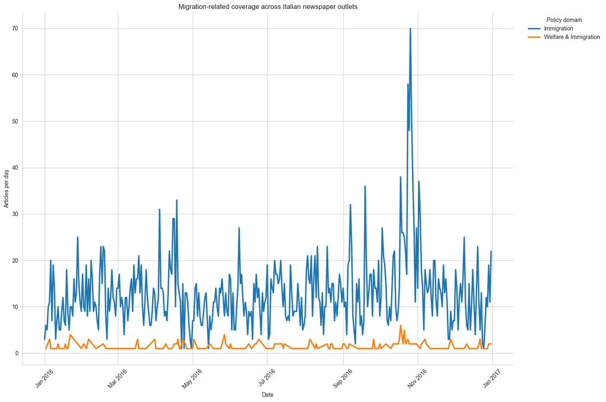

```python
# Graphical style
sns.set_style("whitegrid")

# Plot
plt.figure(figsize=(15,10))

sns.lineplot(
    data=domain_per_day_2016,
    x="publish_date",
    y="count",
    hue="dicht_domain",
    linewidth=2.5
)

# Better x axis fomatting (date formatting)
ax = plt.gca()

ax.xaxis.set_major_locator(mdates.MonthLocator(interval=2))
ax.xaxis.set_major_formatter(
    mdates.DateFormatter("%b %Y")
)                                  #show the x-label every 2 months (shortened format)

plt.xticks(rotation=45)            #rotating the x-label of 45 degree

# Labels
plt.xlabel("Date")
plt.ylabel("Articles per day")
plt.title("Migration-related coverage across Italian newspaper outlets")

# Legend
plt.legend(
    title="Policy domain",
    frameon=False,              #no border
    bbox_to_anchor=(1.02, 1),   #just outside the graph
    loc="upper left"
)

sns.despine()

plt.tight_layout()
plt.show()
```

```python
domain_outlet_per_day_2016 = (
    df_imm_2016
    .groupby([
        df_imm_2016["publish_date"].dt.date,
        "media_name",
        "media_categories",
        "dicht_domain"
    ])
    .size()
    .reset_index(name="count")
)

domain_outlet_per_day_2016["publish_date"] = pd.to_datetime(
    domain_outlet_per_day_2016["publish_date"]
)

print(domain_outlet_per_day_2016)
```

```
     publish_date              media_name      media_categories  dicht_domain  \
0      2016-01-01  Il Corriere della Sera  Quality Conservative             0
1      2016-01-01           La Repubblica   Quality Progressive             0
2      2016-01-02  Il Corriere della Sera  Quality Conservative             0
3      2016-01-02  Il Corriere della Sera  Quality Conservative             1
4      2016-01-02           La Repubblica   Quality Progressive             0
...           ...                     ...                   ...           ...
1070   2016-12-30                  Libero               Popular             0
1071   2016-12-31  Il Corriere della Sera  Quality Conservative             0
1072   2016-12-31  Il Corriere della Sera  Quality Conservative             1
1073   2016-12-31           La Repubblica   Quality Progressive             0
1074   2016-12-31                  Libero               Popular             0

      count
0         1
1         2
2         4
3         1
4         2
...     ...
1070      4
1071      3
1072      2
1073     10
1074      9

[1075 rows x 5 columns]
```

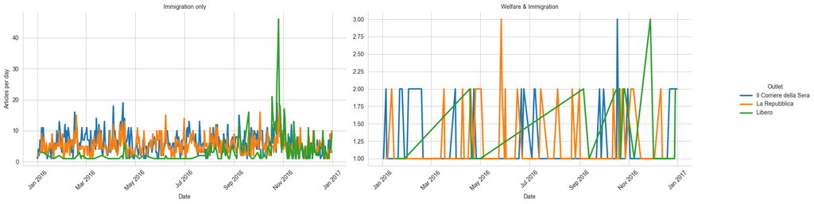

```python
# Ensure datetime
df_imm_2016["publish_date"] = pd.to_datetime(df_imm_2016["publish_date"])

# Rename binary domain labels
df_imm_2016["domain_label"] = df_imm_2016["dicht_domain"].replace({
    0: "Immigration only",
    1: "Welfare & Immigration"
})

# Count articles per day, outlet, and domain
domain_outlet_per_day_2016 = (
    df_imm_2016
    .groupby([
        df_imm_2016["publish_date"].dt.date,
        "media_name",
        "media_categories",
        "domain_label"
    ])
    .size()
    .reset_index(name="count")
)

# Plot
sns.set_style("whitegrid")

g = sns.relplot(
    data=domain_outlet_per_day_2016,
    x="publish_date",
    y="count",
    hue="media_name",
    col="domain_label",
    kind="line",
    linewidth=2.5,
    height=5,
    aspect=1.5,
    facet_kws={"sharey": False}
)

# Format axes
for ax in g.axes.flat:
    ax.xaxis.set_major_locator(mdates.MonthLocator(interval=2))
    ax.xaxis.set_major_formatter(mdates.DateFormatter("%b %Y"))
    ax.tick_params(axis="x", rotation=45)

g.set_axis_labels("Date", "Articles per day")
g.set_titles("{col_name}")

g._legend.set_title("Outlet")
g._legend.set_bbox_to_anchor((1.05, 0.5))
g._legend._loc = 6   # center left

plt.tight_layout()
plt.show()
```

```python
df_imm_pre = df_imm[df_imm["pre_interview"] == 1].copy()
```

```python
# From string to datetime
df_imm_pre["publish_date"] = pd.to_datetime(df_imm_pre["publish_date"])

# Daily counts of news per each outlets
domain_per_day_pre = (
    df_imm_pre
    .groupby(
        [df_imm_pre["publish_date"].dt.date, "dicht_domain"]  #grouping news by dicht_domain per day
    )
    .size()                                             #counting the number of rows (=stories)
    .reset_index(name="count")                          #transformation into a normal DataFrame (count)
)

domain_per_day_pre["dicht_domain"] = (
    domain_per_day_pre["dicht_domain"]
    .replace({
        0: "Immigration",
        1: "Welfare & Immigration"
    })
)

print(domain_per_day_pre)
```

```
    publish_date           dicht_domain  count
0     2017-06-11            Immigration      4
1     2017-06-12            Immigration      3
2     2017-06-13            Immigration     17
3     2017-06-14            Immigration     21
4     2017-06-15            Immigration     20
..           ...                    ...    ...
239   2017-11-16            Immigration      8
240   2017-11-17            Immigration      5
241   2017-11-18            Immigration      2
242   2017-11-19            Immigration      6
243   2017-11-19  Welfare & Immigration      1

[244 rows x 3 columns]
```

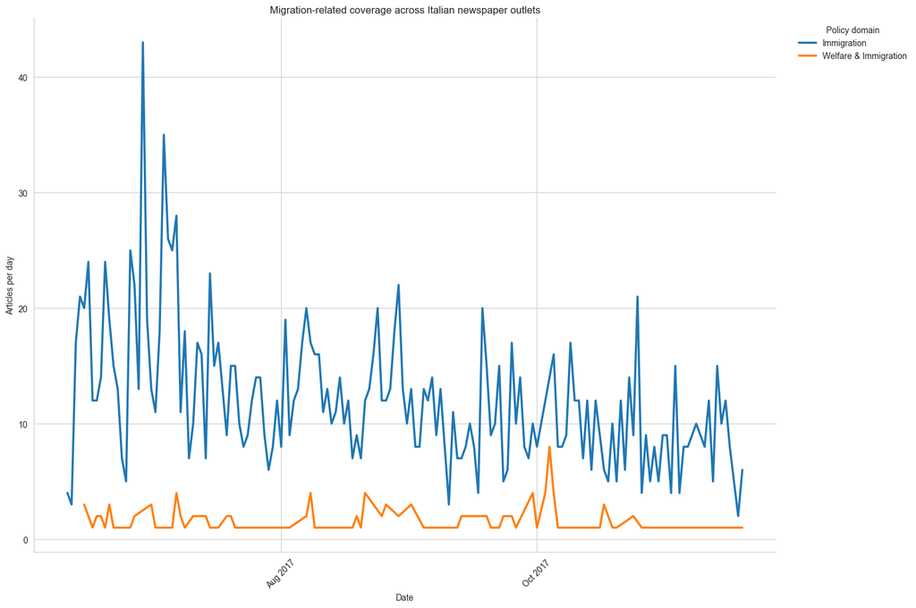

```python
# Graphical style
sns.set_style("whitegrid")

# Plot
plt.figure(figsize=(15,10))

sns.lineplot(
    data=domain_per_day_pre,
    x="publish_date",
    y="count",
    hue="dicht_domain",
    linewidth=2.5
)

# Better x axis fomatting (date formatting)
ax = plt.gca()

ax.xaxis.set_major_locator(mdates.MonthLocator(interval=2))
ax.xaxis.set_major_formatter(
    mdates.DateFormatter("%b %Y")
)                                  #show the x-label every 2 months (shortened format)

plt.xticks(rotation=45)            #rotating the x-label of 45 degree

# Labels
plt.xlabel("Date")
plt.ylabel("Articles per day")
plt.title("Migration-related coverage across Italian newspaper outlets")

# Legend
plt.legend(
    title="Policy domain",
    frameon=False,              #no border
    bbox_to_anchor=(1.02, 1),   #just outside the graph
    loc="upper left"
)

sns.despine()

plt.tight_layout()
plt.show()
```

```python
domain_outlet_per_day_pre = (
    df_imm_pre
    .groupby([
        df_imm_pre["publish_date"].dt.date,
        "media_name",
        "media_categories",
        "dicht_domain"
    ])
    .size()
    .reset_index(name="count")
)

domain_outlet_per_day_pre["publish_date"] = pd.to_datetime(
    domain_outlet_per_day_pre["publish_date"]
)

print(domain_outlet_per_day_pre)
```

```
    publish_date              media_name      media_categories  dicht_domain  \
0     2017-06-11  Il Corriere della Sera  Quality Conservative             0
1     2017-06-11           La Repubblica   Quality Progressive             0
2     2017-06-12           La Repubblica   Quality Progressive             0
3     2017-06-13  Il Corriere della Sera  Quality Conservative             0
4     2017-06-13           La Repubblica   Quality Progressive             0
..           ...                     ...                   ...           ...
560   2017-11-17                  Libero               Popular             0
561   2017-11-18           La Repubblica   Quality Progressive             0
562   2017-11-19  Il Corriere della Sera  Quality Conservative             1
563   2017-11-19           La Repubblica   Quality Progressive             0
564   2017-11-19                  Libero               Popular             0

     count
0        1
1        3
2        3
3        6
4        9
..     ...
560      1
561      2
562      1
563      5
564      1

[565 rows x 5 columns]
```

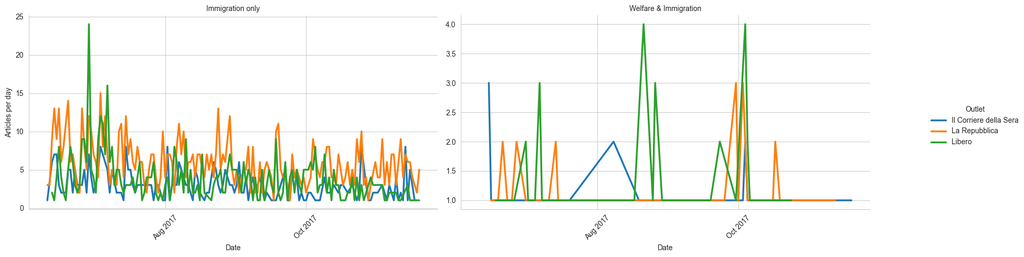

```python
# Ensure datetime
df_imm_pre["publish_date"] = pd.to_datetime(df_imm_pre["publish_date"])

# Rename binary domain labels
df_imm_pre["domain_label"] = df_imm_pre["dicht_domain"].replace({
    0: "Immigration only",
    1: "Welfare & Immigration"
})

# Count articles per day, outlet, and domain
domain_outlet_per_day_pre = (
    df_imm_pre
    .groupby([
        df_imm_pre["publish_date"].dt.date,
        "media_name",
        "media_categories",
        "domain_label"
    ])
    .size()
    .reset_index(name="count")
)

# Plot
sns.set_style("whitegrid")

g = sns.relplot(
    data=domain_outlet_per_day_pre,
    x="publish_date",
    y="count",
    hue="media_name",
    col="domain_label",
    kind="line",
    linewidth=2.5,
    height=5,
    aspect=1.5,
    facet_kws={"sharey": False}
)

# Format axes
for ax in g.axes.flat:
    ax.xaxis.set_major_locator(mdates.MonthLocator(interval=2))
    ax.xaxis.set_major_formatter(mdates.DateFormatter("%b %Y"))
    ax.tick_params(axis="x", rotation=45)

g.set_axis_labels("Date", "Articles per day")
g.set_titles("{col_name}")

g._legend.set_title("Outlet")
g._legend.set_bbox_to_anchor((1.05, 0.5))
g._legend._loc = 6   # center left

plt.tight_layout()
plt.show()
```

```python
df_imm_post = df_imm[df_imm["post_interview"] == 1].copy()
```

```python
# From string to datetime
df_imm_post["publish_date"] = pd.to_datetime(df_imm_post["publish_date"])

# Daily counts of news per each outlets
domain_per_day_post = (
    df_imm_post
    .groupby(
        [df_imm_post["publish_date"].dt.date, "dicht_domain"]  #grouping news by dicht_domain per day
    )
    .size()                                             #counting the number of rows (=stories)
    .reset_index(name="count")                          #transformation into a normal DataFrame (count)
)

domain_per_day_post["dicht_domain"] = (
    domain_per_day_post["dicht_domain"]
    .replace({
        0: "Immigration",
        1: "Welfare & Immigration"
    })
)

print(domain_per_day_post)
```

```
    publish_date           dicht_domain  count
0     2017-09-11            Immigration     11
1     2017-09-12            Immigration      7
2     2017-09-12  Welfare & Immigration      1
3     2017-09-13            Immigration      7
4     2017-09-13  Welfare & Immigration      2
..           ...                    ...    ...
235   2018-02-16            Immigration     11
236   2018-02-17            Immigration      8
237   2018-02-18            Immigration      5
238   2018-02-18  Welfare & Immigration      1
239   2018-02-19            Immigration      9

[240 rows x 3 columns]
```

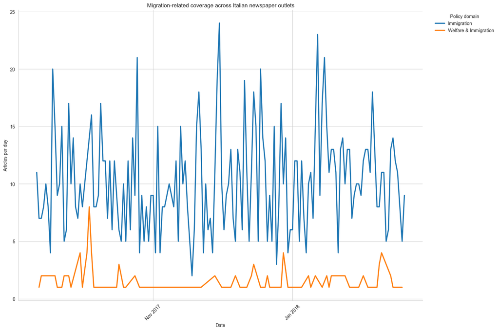

```python
# Graphical style
sns.set_style("whitegrid")

# Plot
plt.figure(figsize=(15,10))

sns.lineplot(
    data=domain_per_day_post,
    x="publish_date",
    y="count",
    hue="dicht_domain",
    linewidth=2.5
)

# Better x axis fomatting (date formatting)
ax = plt.gca()

ax.xaxis.set_major_locator(mdates.MonthLocator(interval=2))
ax.xaxis.set_major_formatter(
    mdates.DateFormatter("%b %Y")
)                                  #show the x-label every 2 months (shortened format)

plt.xticks(rotation=45)            #rotating the x-label of 45 degree

# Labels
plt.xlabel("Date")
plt.ylabel("Articles per day")
plt.title("Migration-related coverage across Italian newspaper outlets")

# Legend
plt.legend(
    title="Policy domain",
    frameon=False,              #no border
    bbox_to_anchor=(1.02, 1),   #just outside the graph
    loc="upper left"
)

sns.despine()

plt.tight_layout()
plt.show()
```

```python
domain_outlet_per_day_post = (
    df_imm_post
    .groupby([
        df_imm_post["publish_date"].dt.date,
        "media_name",
        "dicht_domain"
    ])
    .size()
    .reset_index(name="count")
)

domain_outlet_per_day_post["publish_date"] = pd.to_datetime(
    domain_outlet_per_day_post["publish_date"]
)

print(domain_outlet_per_day_post)
```

```
    publish_date              media_name  dicht_domain  count
0     2017-09-11  Il Corriere della Sera             0      4
1     2017-09-11           La Repubblica             0      6
2     2017-09-11                  Libero             0      1
3     2017-09-12           La Repubblica             0      2
4     2017-09-12           La Repubblica             1      1
..           ...                     ...           ...    ...
541   2018-02-18  Il Corriere della Sera             1      1
542   2018-02-18           La Repubblica             0      4
543   2018-02-19  Il Corriere della Sera             0      5
544   2018-02-19           La Repubblica             0      2
545   2018-02-19                  Libero             0      2

[546 rows x 4 columns]
```

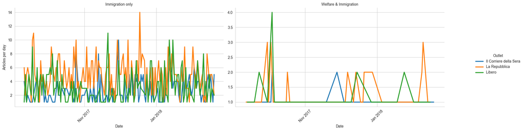

```python
# Ensure datetime
df_imm_post["publish_date"] = pd.to_datetime(df_imm_post["publish_date"])

# Rename binary domain labels
df_imm_post["domain_label"] = df_imm_post["dicht_domain"].replace({
    0: "Immigration only",
    1: "Welfare & Immigration"
})

# Count articles per day, outlet, and domain
domain_outlet_per_day_post = (
    df_imm_post
    .groupby([
        df_imm_post["publish_date"].dt.date,
        "media_name",
        "domain_label"
    ])
    .size()
    .reset_index(name="count")
)

# Plot
sns.set_style("whitegrid")

g = sns.relplot(
    data=domain_outlet_per_day_post,
    x="publish_date",
    y="count",
    hue="media_name",
    col="domain_label",
    kind="line",
    linewidth=2.5,
    height=5,
    aspect=1.5,
    facet_kws={"sharey": False}
)

# Format axes
for ax in g.axes.flat:
    ax.xaxis.set_major_locator(mdates.MonthLocator(interval=2))
    ax.xaxis.set_major_formatter(mdates.DateFormatter("%b %Y"))
    ax.tick_params(axis="x", rotation=45)

g.set_axis_labels("Date", "Articles per day")
g.set_titles("{col_name}")

g._legend.set_title("Outlet")
g._legend.set_bbox_to_anchor((1.05, 0.5))
g._legend._loc = 6   # center left

plt.tight_layout()
plt.show()
```